# Lab: Nonlinear Regression

36-600

```r
suppressMessages(library(tidyverse))
```

## Data

We’ll begin by simulating a dataset from a nonlinear curve:

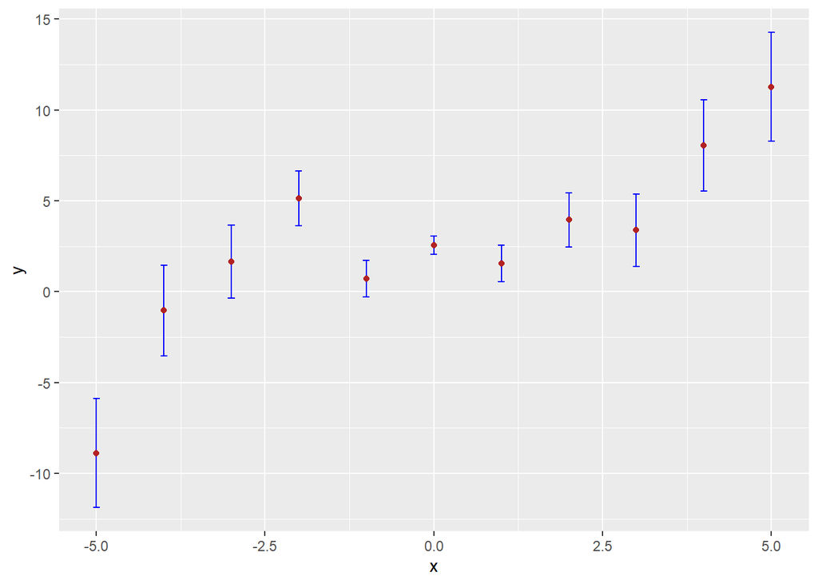

```r
set.seed(555)
x <- -5:5
y <- 0.1*x^3 - 0.5*x + 2.1 + rnorm(length(x),mean=0,sd=0.5*(1+abs(x)))
e <- 0.5*(1+abs(x))

df <- data.frame("x"=x,"y"=y,"e"=e)

suppressMessages(library(tidyverse))
ggplot(data=df,mapping=aes(x=x,y=y)) +
  geom_errorbar(aes(ymin=y-e, ymax=y+e), width=.1,color="blue") +
  geom_point(color="firebrick")
```

# Questions

## Question 1

Implement a (weighted) global cubic polynomial regression model in a similar manner to that implemented in the notes; namely, that means learn the model, run predict to determine the regression line, plot the data with the regression line superimposed, show the coefficients, and compute the mean-squared error. Like we did(n’t do) in the notes, do not split the data into training and test datasets.

```
## [1] 1.930721
```

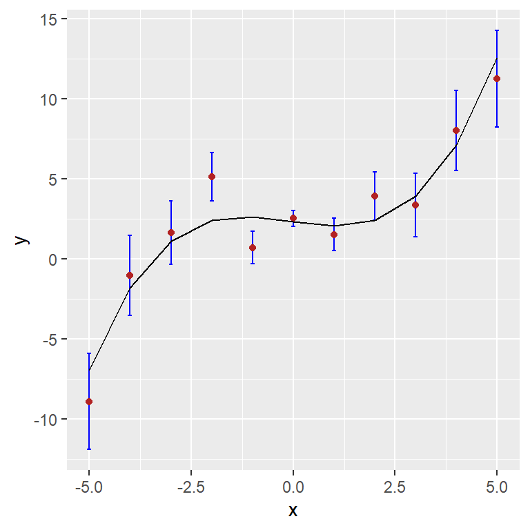

## Question 2

Repeat Q1, but utilizing a regression splines model. Assume four degrees of freedom.

```
## [1] 1.150384
```

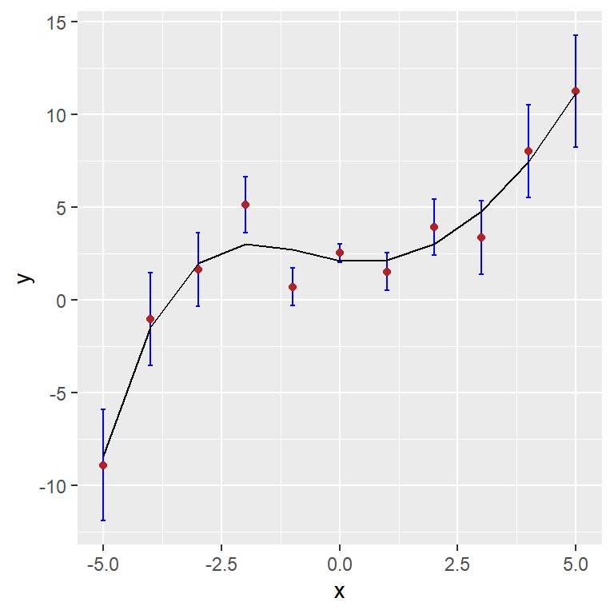

## Question 3

Repeat Q1, but with a smoothing spline model. Note that you may get a “surprising” result.

```
## [1] 9.351152
```

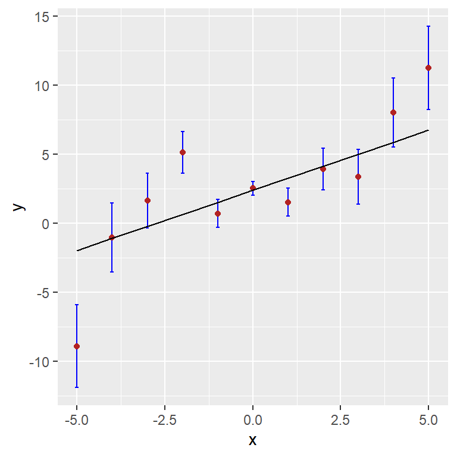

## Question 4

Repeat Q1, but with a local polynomial regression model. Assume a `span` of 0.6.

```r
lpr.out <- loess(y~x,data=df,weights=1/(df$e)^2,span=0.6)
lpr.pred <- predict(lpr.out)
mean((y-lpr.pred)^2)
```

```
## [1] 1.596355
```

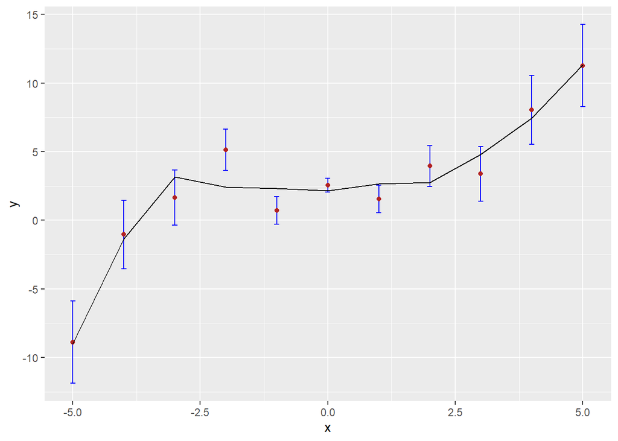

```r
ggplot(data=df,mapping=aes(x=x,y=y)) +
  geom_errorbar(aes(ymin=y-e, ymax=y+e), width=.1,color="blue") +
  geom_point(color="firebrick")+
  geom_line(aes(y = lpr.pred))
```

## Question 5

Redo the plot in Q4, but let’s add a one-standard-error confidence band. You can do this by running the first line, then adding the last two lines onto your `ggplot()` call:

```
p <- predict(lpr.out,se=TRUE)

+ geom_line(mapping=aes(x=lpr.out$x,y=lpr.out$fitted+p$se),color="[your color]",linetype="dashed")
+ geom_line(mapping=aes(x=lpr.out$x,y=lpr.out$fitted-p$se),color="[your color]",linetype="dashed")
```

What does the band actually mean? Because it’s a one-standard-error band, it means that for any given $x$, there is an approximately 68% chance that the band overlaps the true underlying function value. This is a rough statement, though, given the correlation between neighboring data points (i.e., the lack of independence between $y_{i-1}$, $y_i$, and $y_{i+1}$, etc.). Just think of the band as a notion of how uncertain your fitted curve is at each $x$: is the band thin, or wide? Note that the bands get wider as we get to either end of the data: this is an expected feature, not a bug. There’s fewer data within the span at either end, so the fitted function is that much more uncertain.

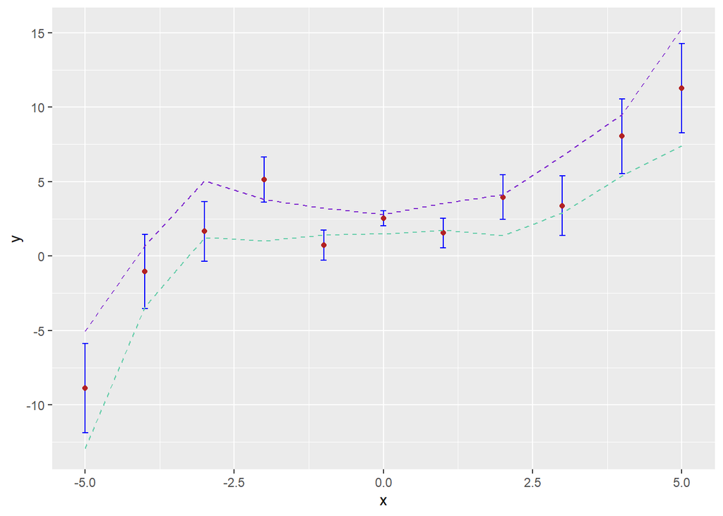

```r
p <- predict(lpr.out,se=TRUE)
ggplot(data=df,mapping=aes(x=x,y=y)) +
  geom_errorbar(aes(ymin=y-e, ymax=y+e), width=.1,color="blue") +
  geom_point(color="firebrick")+
 geom_line(mapping=aes(x=lpr.out$x,y=lpr.out$fitted+p$se),color="purple3",linetype="dashed")+
 geom_line(mapping=aes(x=lpr.out$x,y=lpr.out$fitted-p$se),color="aquamarine3",linetype="dashed")
```